# 002 incidence

Katie Gostic

11/1/2017

Notes on data formatting from Deborah Wentworth:

- symdur is symptom duration (days) prior to enrollment
- date info is for enrollment date
- fluvac6 and fluvac12 are flu vaccination in last 6 or last 12 months
- anyvac combines values from fluvac6 and fluvac12, whichever was collected for a given patient is reported.
- anyav is use of antivirals at any time
- anydx is any diagnosis in the medical history section
- flutype is subtype: 1=H1N1, 2=H3N2, 3=flu B, 4=PCR negative, 5=Inf A, subtype unknown, and 6=coinfection with multiple strains
- resolved is symptom resolution within 14 days
- country code is the 3 letter code for country of enrollment - think the abbreviations will be obvious

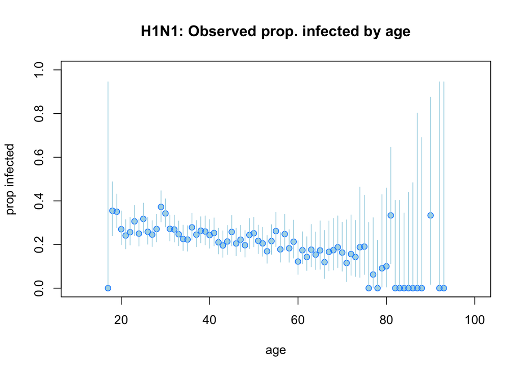

#### Visualize the relationship between age and prob of H3N2 infection

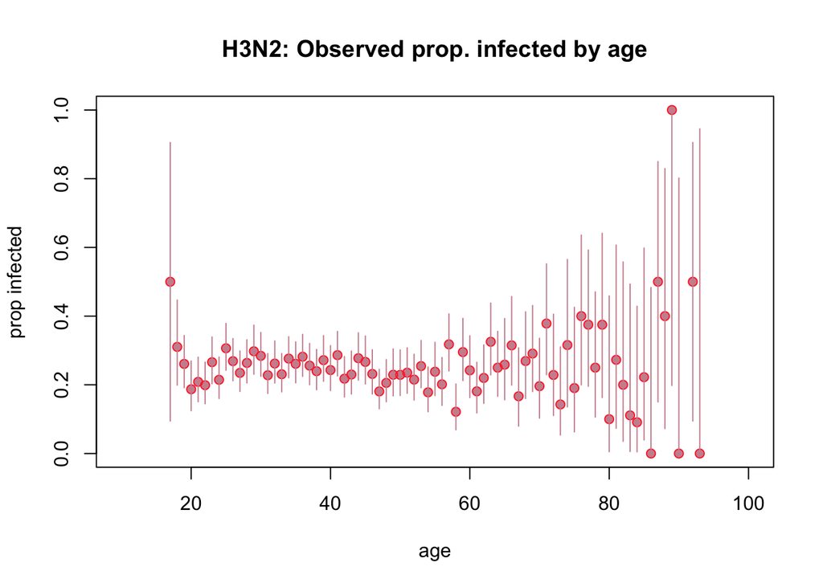

#### Visualize the relationship between country and prob infection

H1N1

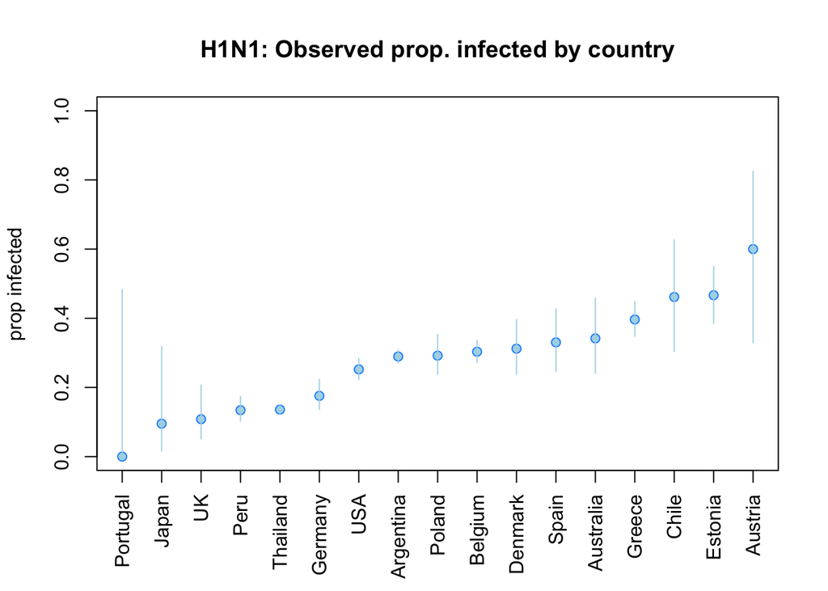

H3N2

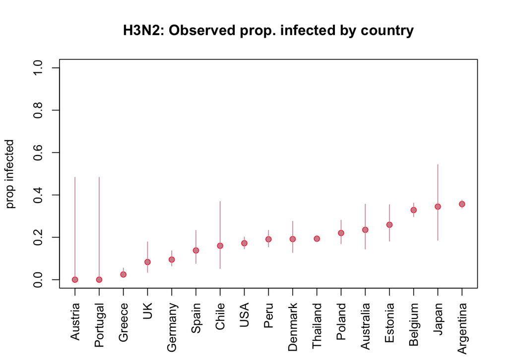

#### Visualize the relationship between season and prob infection

H1N1

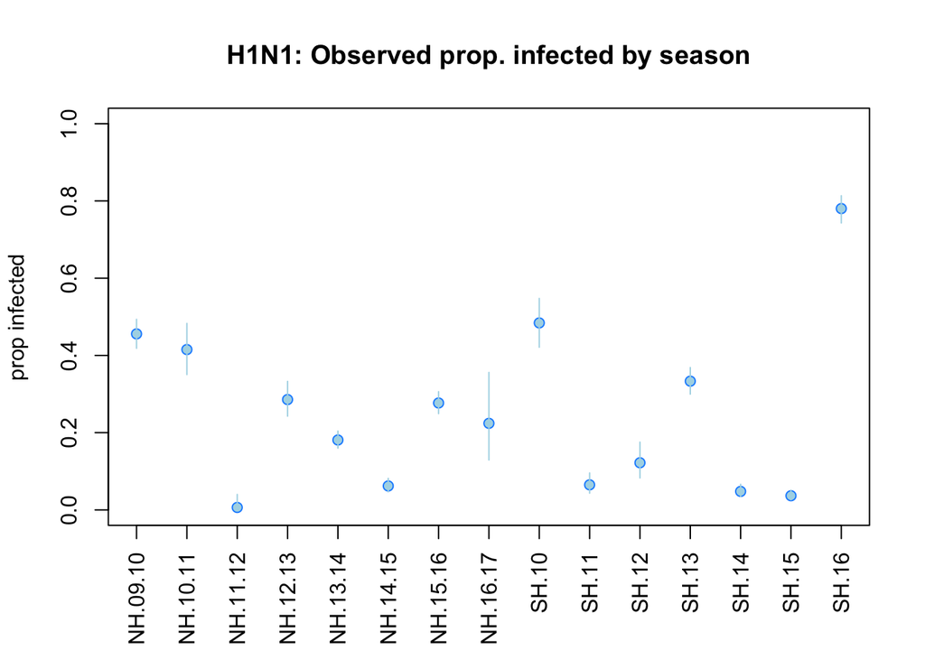

H3N2

[figure not shown]

- age
- imprinting status
- vaccination status
- antiviral use
- season
- country

### Clean data for fitting

```
##
## Argentina Australia   Austria   Belgium     Chile   Denmark   Estonia
##      2277        79        15       820        39       141       150
##   Germany    Greece     Japan      Peru    Poland  Portugal     Spain
##       313       395        21       387       250         6       112
##  Thailand        UK       USA
##      2510        74       817
```

```
## [1] 8406
```

```
##
## Argentina Australia   Austria   Belgium     Chile   Denmark   Estonia
##      2516        68         6       851        25       120       108
##   Germany    Greece     Japan      Peru    Poland  Portugal     Spain
##       285       244        29       414       227         6        87
##  Thailand        UK       USA
##      2689        72       738
```

```
## [1] 8485
```

### First fit a model where the only independent variable is age

Treat vaccination, antivial use, underlying symptoms, country and season as blocking variables with fixed effects

```r
library(splines)
library(ROCR)
```

```r
## Fit to country, season and medical history only (no effect of age or imprinting)
fit0 = glm(infected ~ anyav + anydx + country + H3.valid*season + H3.valid*anyvac, data = train, family = binomial)
summary(fit0)
```

```
##
## Call:
## glm(formula = infected ~ anyav + anydx + country + H3.valid *
##     season + H3.valid * anyvac, family = binomial, data = train)
##
## Deviance Residuals:
##     Min       1Q   Median       3Q      Max
## -2.2466  -0.7410  -0.4540  -0.0003   3.2107
##
## Coefficients:
##                           Estimate Std. Error z value Pr(>|z|)
## (Intercept)                0.66899    0.12875   5.196 2.04e-07 ***
## anyav1                     0.88160    0.07817  11.277  < 2e-16 ***
## anydx1                    -0.22342    0.04799  -4.655 3.24e-06 ***
## countryAustralia          -0.53373    0.23125  -2.308 0.020998 *
## countryBelgium            -0.13824    0.10795  -1.281 0.200317
## countryChile               2.83024    0.50209   5.637 1.73e-08 ***
## countryDenmark            -0.52255    0.18417  -2.837 0.004549 **
## countryEstonia            -0.08143    0.17331  -0.470 0.638464
## countryGermany            -1.10494    0.16544  -6.679 2.41e-11 ***
## countryGreece             -0.73187    0.14305  -5.116 3.12e-07 ***
## countryJapan              -0.50757    0.79388  -0.639 0.522594
## countryOther              -0.50006    0.29630  -1.688 0.091471 .
## countryPeru               -1.14429    0.12091  -9.464  < 2e-16 ***
## countryPoland             -0.56782    0.14902  -3.810 0.000139 ***
## countrySpain              -1.08905    0.20294  -5.366 8.04e-08 ***
## countryThailand           -0.78640    0.07709 -10.201  < 2e-16 ***
## countryUK                 -1.54112    0.31312  -4.922 8.57e-07 ***
## countryUSA                -0.71982    0.11418  -6.304 2.90e-10 ***
## H3.valid1                -16.48012  127.72199  -0.129 0.897333
## seasonNH.10.11            -0.40795    0.18037  -2.262 0.023711 *
## seasonNH.11.12            -5.09781    1.01008  -5.047 4.49e-07 ***
## seasonNH.12.13            -1.00311    0.15583  -6.437 1.22e-10 ***
## seasonNH.13.14            -1.26684    0.12662 -10.005  < 2e-16 ***
## seasonNH.14.15            -2.56429    0.18402 -13.935  < 2e-16 ***
## seasonNH.15.16            -0.83369    0.11981  -6.958 3.44e-12 ***
## seasonNH.16.17            -0.85965    0.34300  -2.506 0.012202 *
## seasonSH.10               -0.19613    0.18297  -1.072 0.283769
## seasonSH.11               -3.95916    0.33519 -11.812  < 2e-16 ***
## seasonSH.12               -2.20907    0.25602  -8.628  < 2e-16 ***
```

[output cut: 17 more lines]

```
## H3.valid1:seasonSH.14     18.72754  127.72216   0.147 0.883426
## H3.valid1:seasonSH.15     18.73128  127.72213   0.147 0.883403
## H3.valid1:seasonSH.16     15.26468  127.72214   0.120 0.904868
## H3.valid1:anyvac1          0.46474    0.11202   4.149 3.34e-05 ***
## H3.valid1:anyvac2         -0.09192    0.81304  -0.113 0.909987
## ---
## Signif. codes:  0 '***' 0.001 '**' 0.01 '*' 0.05 '.' 0.1 ' ' 1
##
## (Dispersion parameter for binomial family taken to be 1)
##
##     Null deviance: 16552  on 14890  degrees of freedom
## Residual deviance: 13598  on 14840  degrees of freedom
## AIC: 13700
##
## Number of Fisher Scoring iterations: 15
```

```r
## H1N1 fit to age only, plus fixed effects of vaccination, av use, underlying conditions, country and season
fit1 = glm(infected ~ anyav + anydx + country + ns(age, knots = 65) + H3.valid*season + H3.valid*anyvac, data = train, family = binomial)
summary(fit1)
```

```
##
## Call:
## glm(formula = infected ~ anyav + anydx + country + ns(age, knots = 65) +
##     H3.valid * season + H3.valid * anyvac, family = binomial,
##     data = train)
##
## Deviance Residuals:
##     Min       1Q   Median       3Q      Max
## -2.2472  -0.7416  -0.4566  -0.0003   3.2102
##
## Coefficients:
##                           Estimate Std. Error z value Pr(>|z|)
## (Intercept)                0.66961    0.13393   5.000 5.74e-07 ***
## anyav1                     0.88367    0.07821  11.298  < 2e-16 ***
## anydx1                    -0.21437    0.05002  -4.286 1.82e-05 ***
## countryAustralia          -0.53464    0.23143  -2.310 0.020881 *
## countryBelgium            -0.13482    0.10832  -1.245 0.213248
## countryChile               2.82660    0.50220   5.628 1.82e-08 ***
## countryDenmark            -0.52131    0.18421  -2.830 0.004655 **
## countryEstonia            -0.08302    0.17330  -0.479 0.631893
## countryGermany            -1.10808    0.16562  -6.690 2.22e-11 ***
## countryGreece             -0.72889    0.14319  -5.090 3.57e-07 ***
## countryJapan              -0.51334    0.79395  -0.647 0.517914
## countryOther              -0.50509    0.29640  -1.704 0.088361 .
## countryPeru               -1.14752    0.12100  -9.484  < 2e-16 ***
## countryPoland             -0.56713    0.14903  -3.806 0.000141 ***
## countrySpain              -1.07570    0.20356  -5.285 1.26e-07 ***
## countryThailand           -0.78318    0.07723 -10.141  < 2e-16 ***
## countryUK                 -1.53631    0.31325  -4.904 9.37e-07 ***
## countryUSA                -0.72202    0.11434  -6.315 2.71e-10 ***
## ns(age, knots = 65)1      -0.10822    0.15478  -0.699 0.484428
## ns(age, knots = 65)2      -0.15450    0.24103  -0.641 0.521505
## H3.valid1                -16.47919  127.71491  -0.129 0.897333
## seasonNH.10.11            -0.40653    0.18053  -2.252 0.024333 *
## seasonNH.11.12            -5.09332    1.01015  -5.042 4.60e-07 ***
## seasonNH.12.13            -0.99981    0.15626  -6.399 1.57e-10 ***
## seasonNH.13.14            -1.26293    0.12714  -9.933  < 2e-16 ***
## seasonNH.14.15            -2.56139    0.18427 -13.900  < 2e-16 ***
## seasonNH.15.16            -0.82930    0.12039  -6.889 5.64e-12 ***
## seasonNH.16.17            -0.85424    0.34345  -2.487 0.012875 *
```

[output cut: 20 more lines]

```
## H3.valid1:seasonSH.14     18.72631  127.71508   0.147 0.883427
## H3.valid1:seasonSH.15     18.72966  127.71505   0.147 0.883407
## H3.valid1:seasonSH.16     15.26402  127.71506   0.120 0.904866
## H3.valid1:anyvac1          0.46441    0.11203   4.145 3.39e-05 ***
## H3.valid1:anyvac2         -0.08804    0.81327  -0.108 0.913793
## ---
## Signif. codes:  0 '***' 0.001 '**' 0.01 '*' 0.05 '.' 0.1 ' ' 1
##
## (Dispersion parameter for binomial family taken to be 1)
##
##     Null deviance: 16552  on 14890  degrees of freedom
## Residual deviance: 13597  on 14838  degrees of freedom
## AIC: 13703
##
## Number of Fisher Scoring iterations: 15
```

```r
## H1N1 fit to age plus imprinting, plus fixed effects of vaccination, av use, underlying conditions, country and season
fit2 = glm(infected ~ anyav + anydx + country + ns(age, knots = 65) + p.protected + H3.valid*season + H3.valid*anyvac, data = train, family = binomial)
summary(fit2)
```

```
##
## Call:
## glm(formula = infected ~ anyav + anydx + country + ns(age, knots = 65) +
##     p.protected + H3.valid * season + H3.valid * anyvac, family = binomial,
##     data = train)
##
## Deviance Residuals:
##     Min       1Q   Median       3Q      Max
## -2.2588  -0.7429  -0.4582  -0.0003   3.1995
##
## Coefficients:
##                           Estimate Std. Error z value Pr(>|z|)
## (Intercept)                0.72415    0.13710   5.282 1.28e-07 ***
## anyav1                     0.88544    0.07823  11.319  < 2e-16 ***
## anydx1                    -0.21338    0.05002  -4.266 1.99e-05 ***
## countryAustralia          -0.53490    0.23140  -2.312 0.020800 *
## countryBelgium            -0.13795    0.10834  -1.273 0.202910
## countryChile               2.82345    0.50290   5.614 1.97e-08 ***
## countryDenmark            -0.52435    0.18418  -2.847 0.004415 **
## countryEstonia            -0.09243    0.17347  -0.533 0.594162
## countryGermany            -1.11378    0.16563  -6.725 1.76e-11 ***
## countryGreece             -0.73103    0.14324  -5.103 3.34e-07 ***
## countryJapan              -0.51105    0.79325  -0.644 0.519415
## countryOther              -0.50892    0.29650  -1.716 0.086085 .
## countryPeru               -1.15277    0.12104  -9.524  < 2e-16 ***
## countryPoland             -0.56953    0.14907  -3.821 0.000133 ***
## countrySpain              -1.07201    0.20329  -5.273 1.34e-07 ***
## countryThailand           -0.78745    0.07728 -10.190  < 2e-16 ***
## countryUK                 -1.53936    0.31325  -4.914 8.91e-07 ***
## countryUSA                -0.72914    0.11444  -6.371 1.87e-10 ***
## ns(age, knots = 65)1      -0.14783    0.15638  -0.945 0.344500
## ns(age, knots = 65)2      -0.20854    0.24331  -0.857 0.391386
## p.protected               -0.11578    0.06165  -1.878 0.060377 .
## H3.valid1                -16.46296  127.72135  -0.129 0.897439
## seasonNH.10.11            -0.40008    0.18064  -2.215 0.026777 *
## seasonNH.11.12            -5.08637    1.01015  -5.035 4.77e-07 ***
## seasonNH.12.13            -0.99686    0.15635  -6.376 1.82e-10 ***
## seasonNH.13.14            -1.25598    0.12719  -9.875  < 2e-16 ***
## seasonNH.14.15            -2.56306    0.18430 -13.907  < 2e-16 ***
## seasonNH.15.16            -0.82910    0.12043  -6.885 5.79e-12 ***
```

[output cut: 21 more lines]

```
## H3.valid1:seasonSH.14     18.71952  127.72152   0.147 0.883475
## H3.valid1:seasonSH.15     18.72290  127.72149   0.147 0.883454
## H3.valid1:seasonSH.16     15.26692  127.72150   0.120 0.904853
## H3.valid1:anyvac1          0.44300    0.11262   3.934 8.37e-05 ***
## H3.valid1:anyvac2         -0.10566    0.81383  -0.130 0.896705
## ---
## Signif. codes:  0 '***' 0.001 '**' 0.01 '*' 0.05 '.' 0.1 ' ' 1
##
## (Dispersion parameter for binomial family taken to be 1)
##
##     Null deviance: 16552  on 14890  degrees of freedom
## Residual deviance: 13594  on 14837  degrees of freedom
## AIC: 13702
##
## Number of Fisher Scoring iterations: 15
```

```r
# Add imprinting at H.subtype level
fit3 = glm(infected ~ anyav + anydx + country + ns(age, knots = 65) + p.H.subtype + H3.valid*season + H3.valid*anyvac, data = train, family = binomial)
summary(fit3)
```

```
##
## Call:
## glm(formula = infected ~ anyav + anydx + country + ns(age, knots = 65) +
##     p.H.subtype + H3.valid * season + H3.valid * anyvac, family = binomial,
##     data = train)
##
## Deviance Residuals:
##     Min       1Q   Median       3Q      Max
## -2.2529  -0.7425  -0.4555  -0.0003   3.2073
##
## Coefficients:
##                           Estimate Std. Error z value Pr(>|z|)
## (Intercept)                0.74571    0.13865   5.378 7.52e-08 ***
## anyav1                     0.88548    0.07820  11.323  < 2e-16 ***
## anydx1                    -0.21295    0.05003  -4.256 2.08e-05 ***
## countryAustralia          -0.53810    0.23139  -2.326 0.020044 *
## countryBelgium            -0.14074    0.10836  -1.299 0.193982
## countryChile               2.82427    0.50231   5.623 1.88e-08 ***
## countryDenmark            -0.52597    0.18416  -2.856 0.004290 **
## countryEstonia            -0.08742    0.17340  -0.504 0.614162
## countryGermany            -1.11932    0.16575  -6.753 1.45e-11 ***
## countryGreece             -0.72944    0.14324  -5.093 3.53e-07 ***
## countryJapan              -0.51315    0.79253  -0.647 0.517317
## countryOther              -0.50471    0.29641  -1.703 0.088614 .
## countryPeru               -1.15494    0.12105  -9.541  < 2e-16 ***
## countryPoland             -0.56791    0.14905  -3.810 0.000139 ***
## countrySpain              -1.07004    0.20332  -5.263 1.42e-07 ***
## countryThailand           -0.78714    0.07727 -10.187  < 2e-16 ***
## countryUK                 -1.53998    0.31332  -4.915 8.87e-07 ***
## countryUSA                -0.73356    0.11450  -6.407 1.48e-10 ***
## ns(age, knots = 65)1      -0.23547    0.16644  -1.415 0.157159
## ns(age, knots = 65)2      -0.18532    0.24242  -0.764 0.444596
## p.H.subtype               -0.15391    0.07230  -2.129 0.033270 *
## H3.valid1                -16.43424  127.70066  -0.129 0.897600
## seasonNH.10.11            -0.40918    0.18061  -2.266 0.023480 *
## seasonNH.11.12            -5.08931    1.01017  -5.038 4.70e-07 ***
## seasonNH.12.13            -0.99585    0.15638  -6.368 1.91e-10 ***
## seasonNH.13.14            -1.25434    0.12722  -9.860  < 2e-16 ***
## seasonNH.14.15            -2.55878    0.18432 -13.882  < 2e-16 ***
## seasonNH.15.16            -0.82542    0.12044  -6.853 7.21e-12 ***
```

[output cut: 21 more lines]

```
## H3.valid1:seasonSH.14     18.72269  127.70083   0.147 0.883437
## H3.valid1:seasonSH.15     18.72253  127.70080   0.147 0.883438
## H3.valid1:seasonSH.16     15.26559  127.70081   0.120 0.904846
## H3.valid1:anyvac1          0.44591    0.11239   3.967 7.26e-05 ***
## H3.valid1:anyvac2         -0.08976    0.81314  -0.110 0.912103
## ---
## Signif. codes:  0 '***' 0.001 '**' 0.01 '*' 0.05 '.' 0.1 ' ' 1
##
## (Dispersion parameter for binomial family taken to be 1)
##
##     Null deviance: 16552  on 14890  degrees of freedom
## Residual deviance: 13593  on 14837  degrees of freedom
## AIC: 13701
##
## Number of Fisher Scoring iterations: 15
```

```r
# Add imprinting at N.subtype level
fit4 = glm(infected ~ anyav + anydx + country + ns(age, knots = 65) + p.N.subtype + H3.valid*season + H3.valid*anyvac, data = train, family = binomial)
summary(fit4)
```

```
##
## Call:
## glm(formula = infected ~ anyav + anydx + country + ns(age, knots = 65) +
##     p.N.subtype + H3.valid * season + H3.valid * anyvac, family = binomial,
##     data = train)
##
## Deviance Residuals:
##     Min       1Q   Median       3Q      Max
## -2.2635  -0.7396  -0.4561  -0.0003   3.2033
##
## Coefficients:
##                           Estimate Std. Error z value Pr(>|z|)
## (Intercept)                0.72551    0.13538   5.359 8.37e-08 ***
## anyav1                     0.88410    0.07820  11.306  < 2e-16 ***
## anydx1                    -0.21392    0.05004  -4.275 1.91e-05 ***
## countryAustralia          -0.54070    0.23172  -2.333 0.019626 *
## countryBelgium            -0.13692    0.10835  -1.264 0.206370
## countryChile               2.82841    0.50220   5.632 1.78e-08 ***
## countryDenmark            -0.52330    0.18425  -2.840 0.004510 **
## countryEstonia            -0.09176    0.17350  -0.529 0.596908
## countryGermany            -1.11635    0.16584  -6.731 1.68e-11 ***
## countryGreece             -0.72695    0.14326  -5.074 3.89e-07 ***
## countryJapan              -0.50913    0.79122  -0.643 0.519918
## countryOther              -0.49736    0.29638  -1.678 0.093320 .
## countryPeru               -1.14892    0.12101  -9.494  < 2e-16 ***
## countryPoland             -0.56322    0.14907  -3.778 0.000158 ***
## countrySpain              -1.06844    0.20341  -5.253 1.50e-07 ***
## countryThailand           -0.78317    0.07726 -10.137  < 2e-16 ***
## countryUK                 -1.53904    0.31344  -4.910 9.10e-07 ***
## countryUSA                -0.72011    0.11437  -6.297 3.04e-10 ***
## ns(age, knots = 65)1      -0.16268    0.15632  -1.041 0.298026
## ns(age, knots = 65)2      -0.28877    0.24709  -1.169 0.242531
## p.N.subtype               -0.22393    0.07711  -2.904 0.003682 **
## H3.valid1                -16.38229  127.67413  -0.128 0.897901
## seasonNH.10.11            -0.41751    0.18059  -2.312 0.020779 *
## seasonNH.11.12            -5.10447    1.01021  -5.053 4.35e-07 ***
## seasonNH.12.13            -1.00819    0.15645  -6.444 1.16e-10 ***
## seasonNH.13.14            -1.26607    0.12718  -9.955  < 2e-16 ***
## seasonNH.14.15            -2.56989    0.18439 -13.937  < 2e-16 ***
## seasonNH.15.16            -0.83785    0.12050  -6.953 3.57e-12 ***
```

[output cut: 21 more lines]

```
## H3.valid1:seasonSH.14     18.73060  127.67429   0.147 0.883364
## H3.valid1:seasonSH.15     18.72601  127.67426   0.147 0.883392
## H3.valid1:seasonSH.16     15.26513  127.67427   0.120 0.904829
## H3.valid1:anyvac1          0.45047    0.11220   4.015 5.95e-05 ***
## H3.valid1:anyvac2         -0.04556    0.81283  -0.056 0.955299
## ---
## Signif. codes:  0 '***' 0.001 '**' 0.01 '*' 0.05 '.' 0.1 ' ' 1
##
## (Dispersion parameter for binomial family taken to be 1)
##
##     Null deviance: 16552  on 14890  degrees of freedom
## Residual deviance: 13589  on 14837  degrees of freedom
## AIC: 13697
##
## Number of Fisher Scoring iterations: 15
```

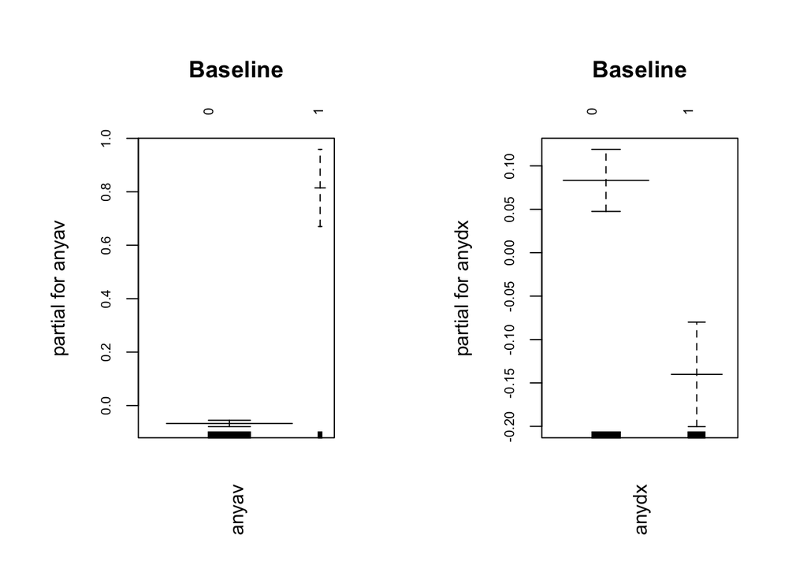

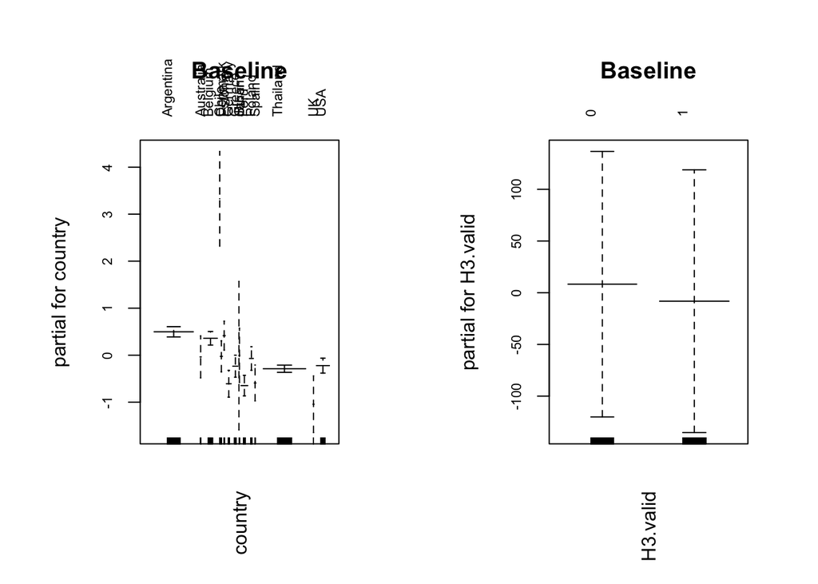

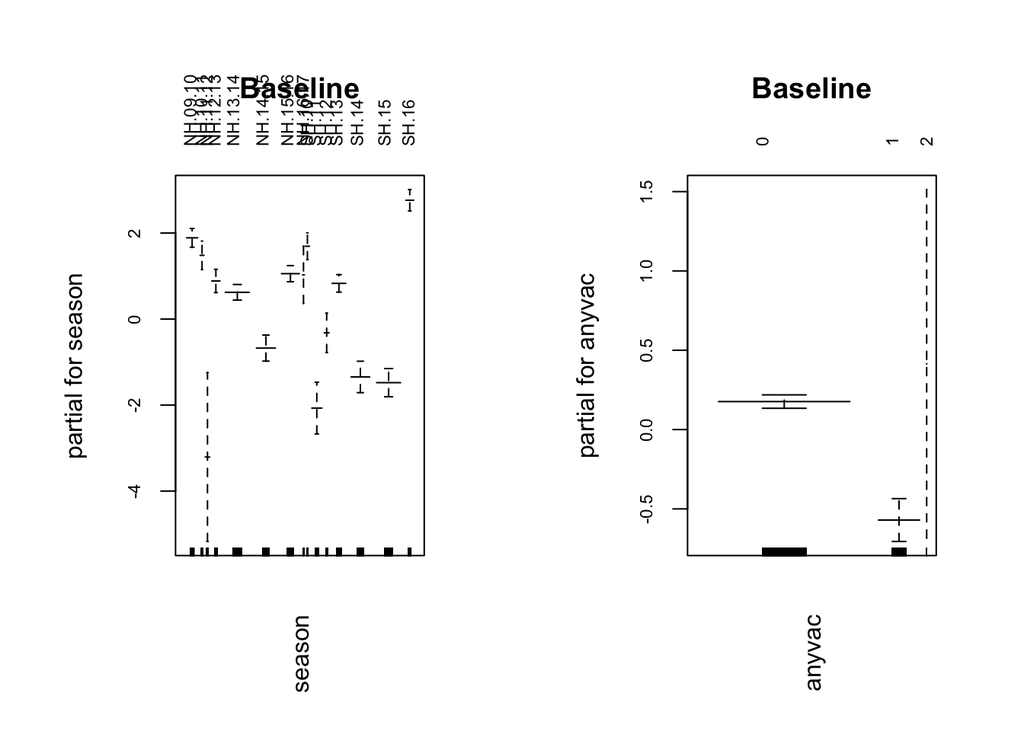

```r
## Plot the fits for each model side by side
par(mfrow = c(1, 2), las = 3, mar = c(6, 6, 6, 3), cex.axis = .7)
library(gam)
plot.gam(fit0, se = T, col = 'darkslateblue', main = 'Baseline')
```

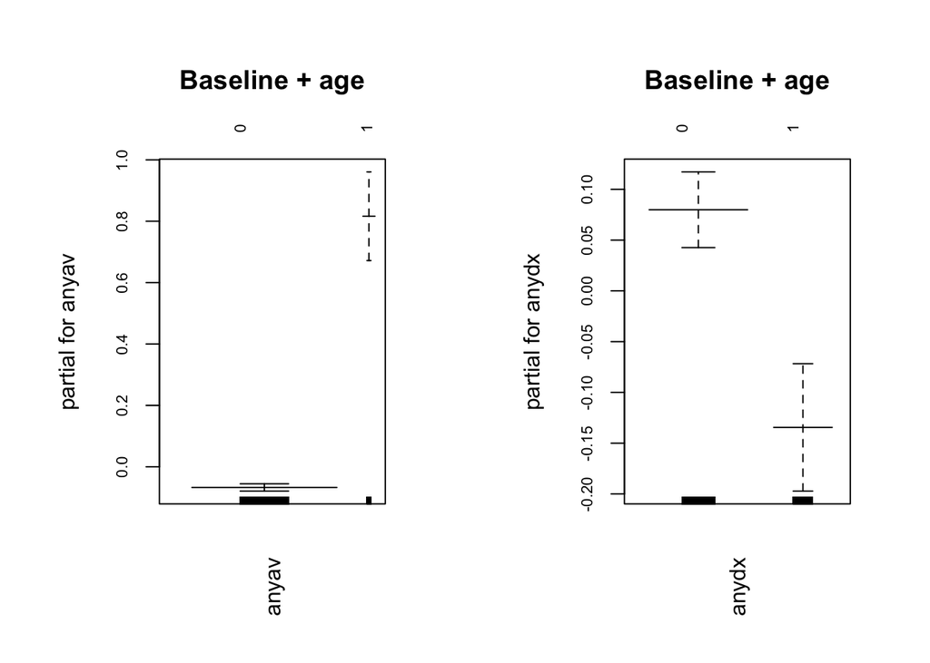

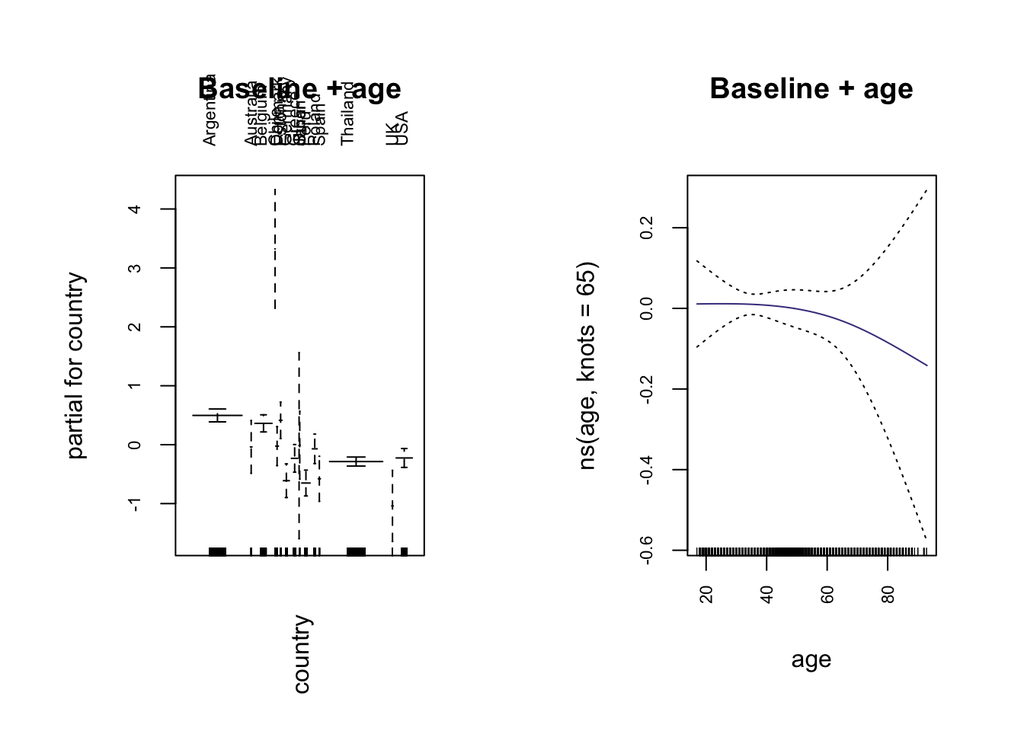

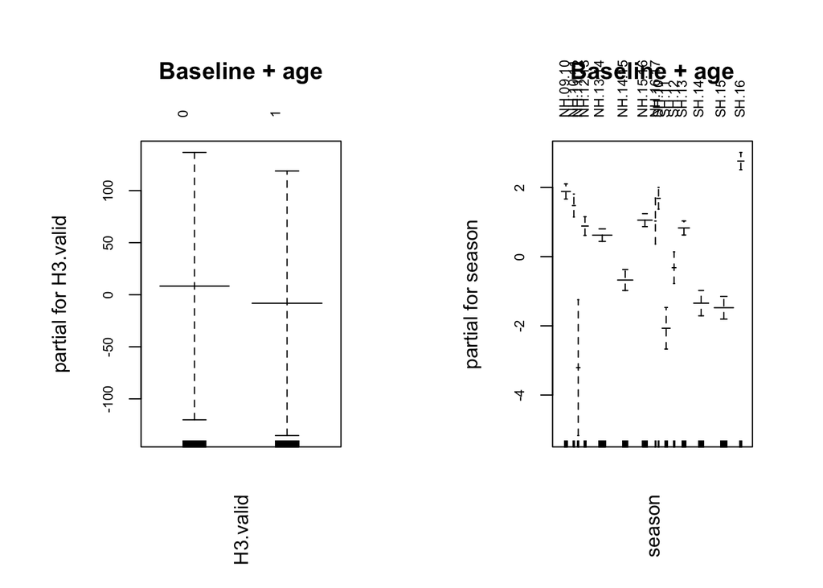

```r
plot.gam(fit1, se = T, col = 'darkslateblue', main = 'Baseline + age')
```

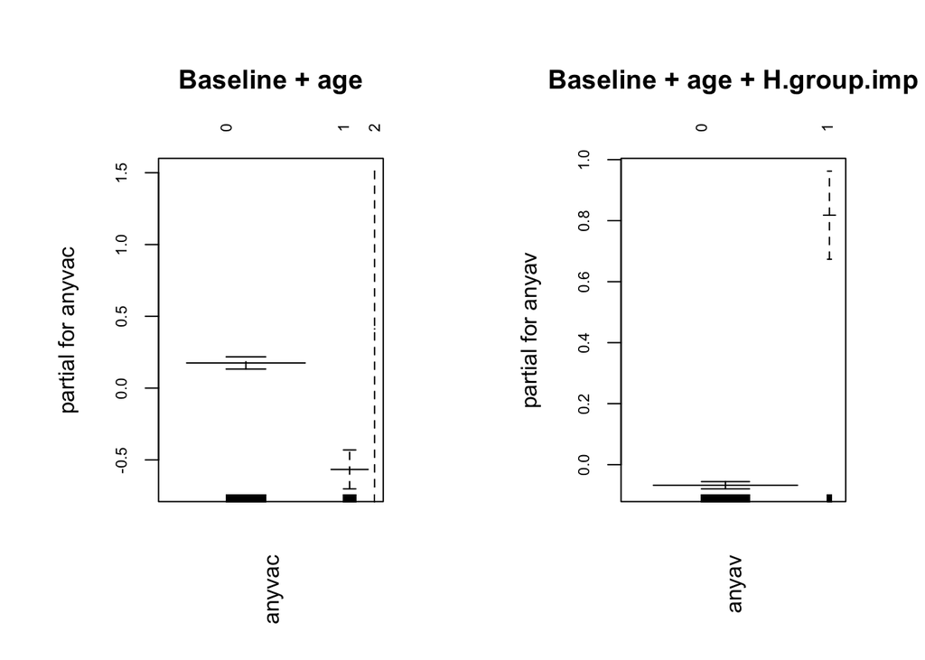

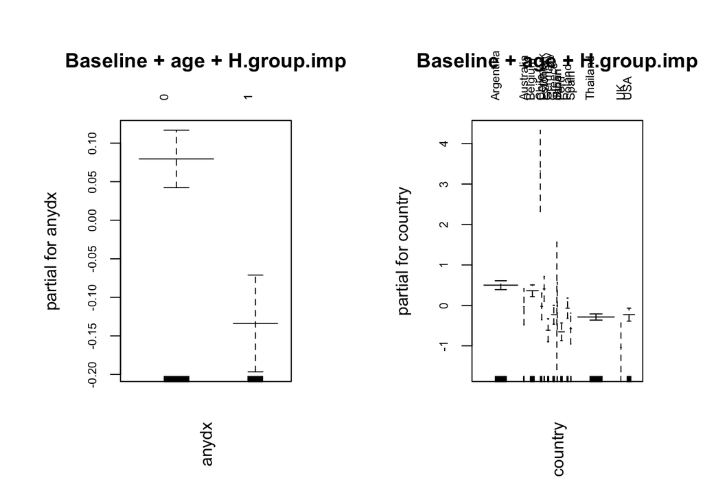

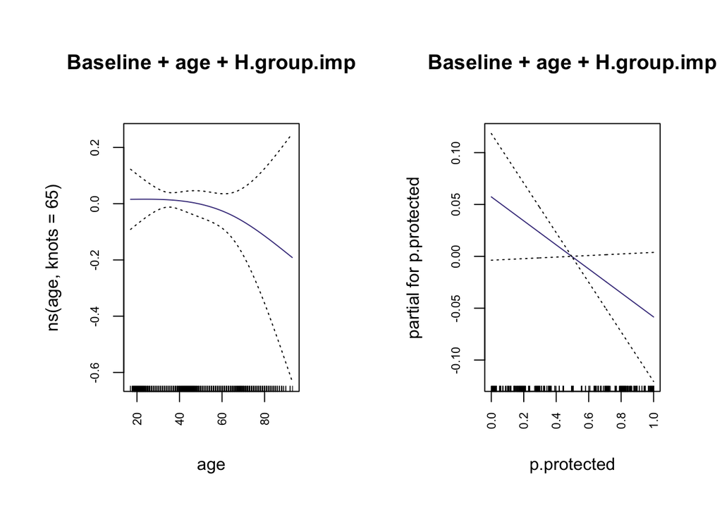

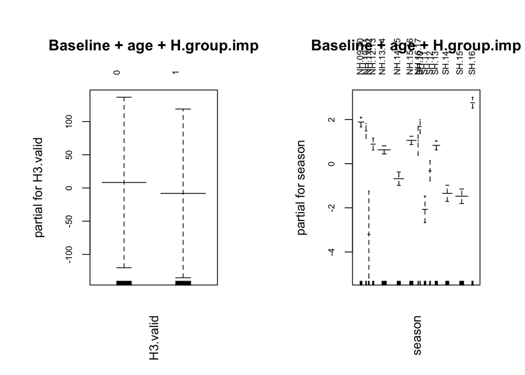

```r
plot.gam(fit2, se = T, col = 'darkslateblue', main = 'Baseline + age + H.group.imp')
```

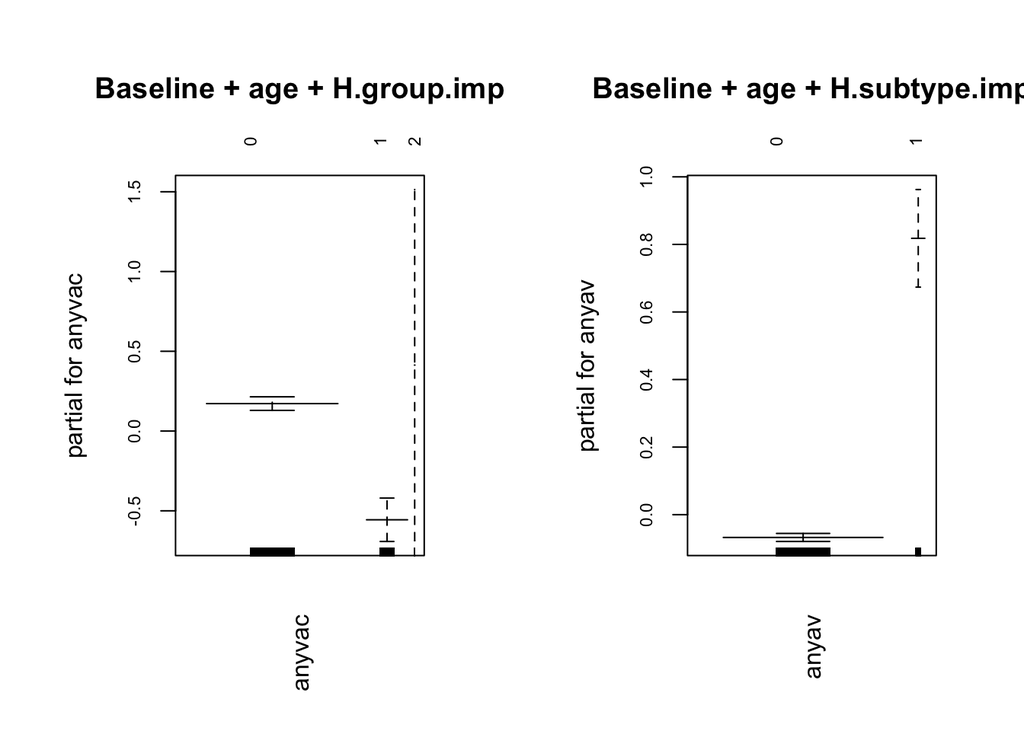

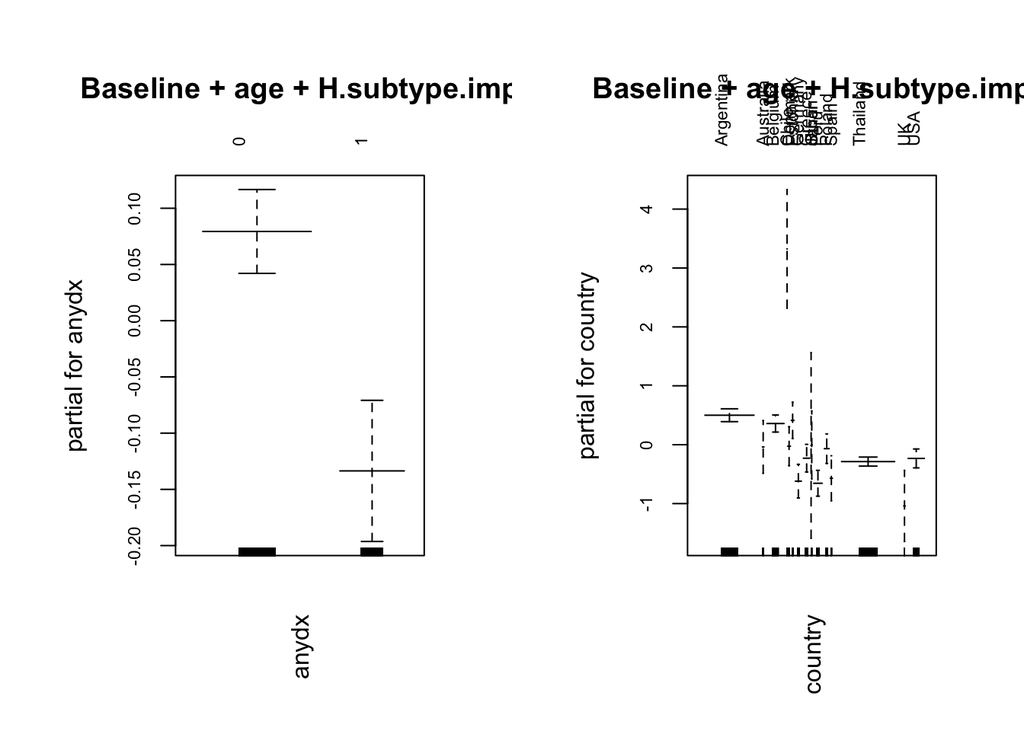

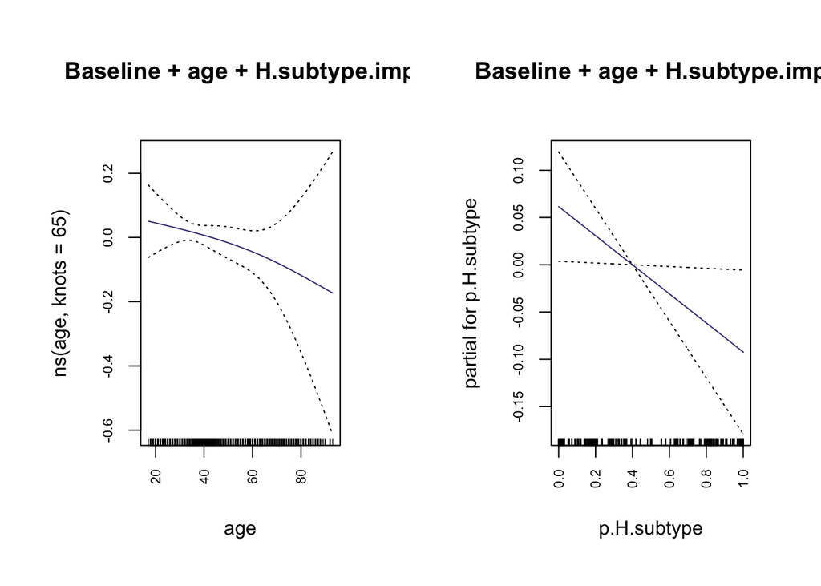

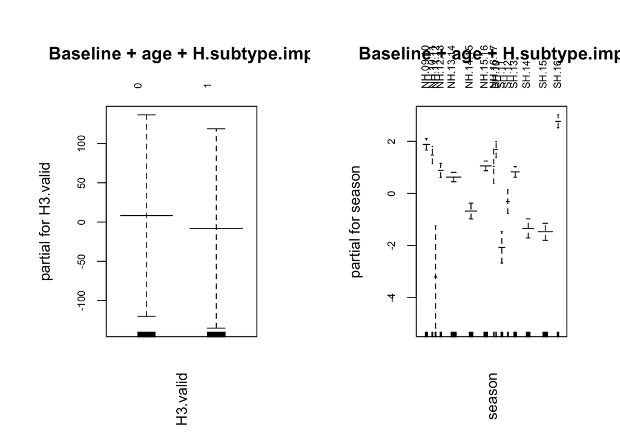

```r
plot.gam(fit3, se = T, col = 'darkslateblue', main = 'Baseline + age + H.subtype.imp')
```

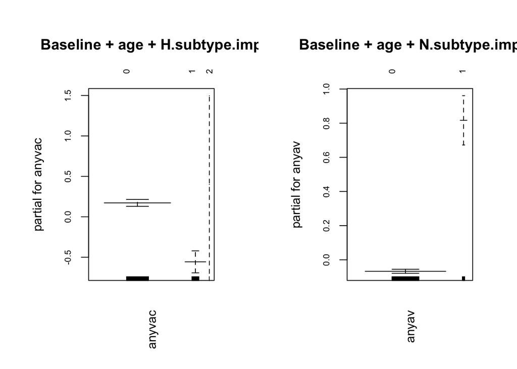

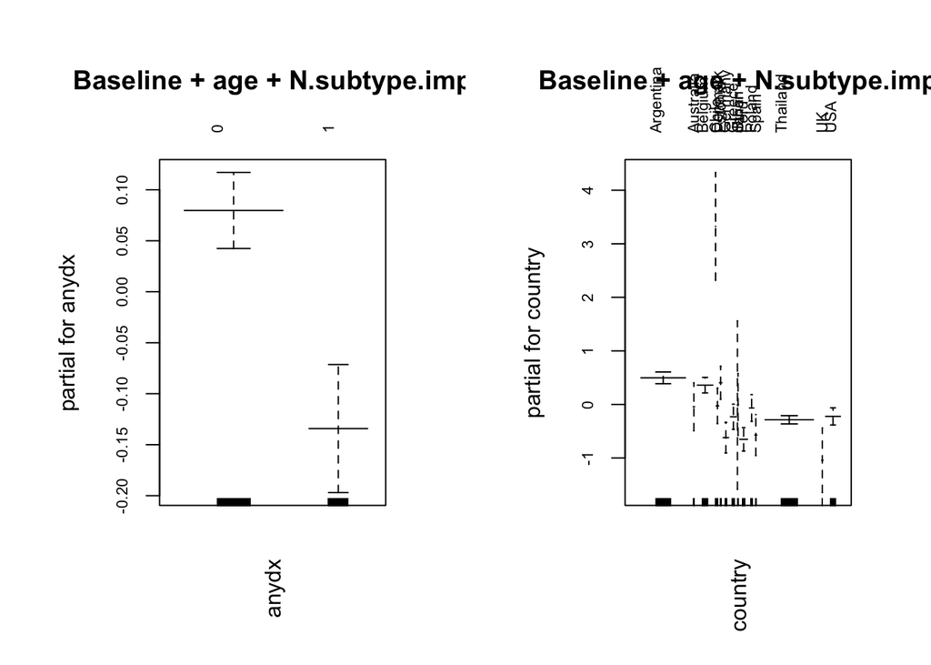

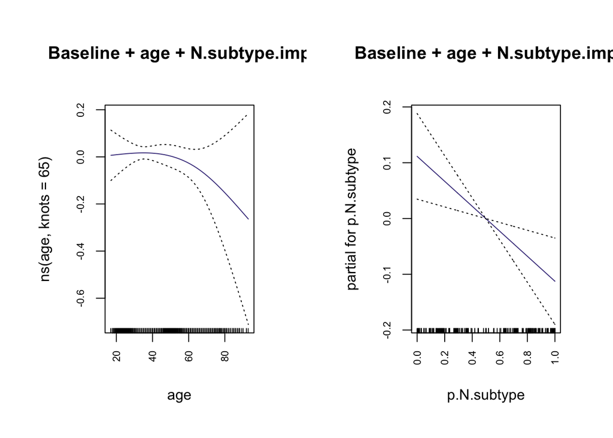

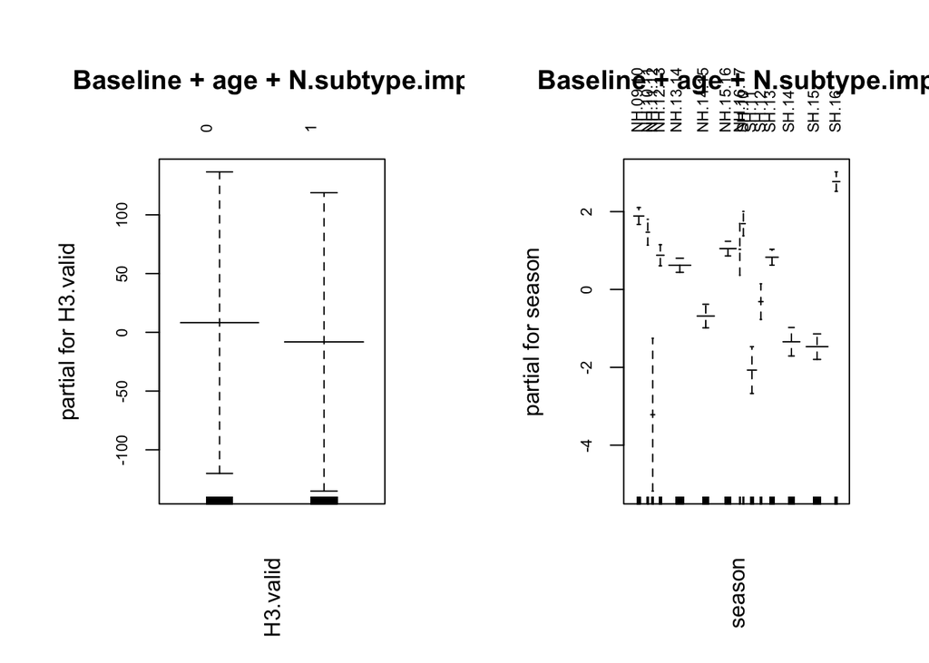

```r
plot.gam(fit4, se = T, col = 'darkslateblue', main = 'Baseline + age + N.subtype.imp')
```

```r
pdf('002Incidence_constrained.pdf')
plot.gam(fit2, se = T, col = 'darkslateblue', main = 'Baseline + age + imp')
dev.off()
```

[figure not shown]

```r
## Test performance on test data
# Predict probs for each patient
probs0 = predict(fit0, newdata = test, type = 'response')
probs1 = predict(fit1, newdata = test, type = 'response')
probs2 = predict(fit2, newdata = test, type = 'response')
probs3 = predict(fit3, newdata = test, type = 'response')
probs4 = predict(fit4, newdata = test, type = 'response')

# Create a predict object
pr0 = prediction(probs0, test$infected)
pr1 = prediction(probs1, test$infected)
pr2 = prediction(probs2, test$infected)
pr3 = prediction(probs3, test$infected)
pr4 = prediction(probs4, test$infected)

# Assess tp and fp
prf0 = performance(pr0, measure = 'tpr', x.measure = 'fpr')
prf1 = performance(pr1, measure = 'tpr', x.measure = 'fpr')
prf2 = performance(pr2, measure = 'tpr', x.measure = 'fpr')
prf3 = performance(pr3, measure = 'tpr', x.measure = 'fpr')
prf4 = performance(pr4, measure = 'tpr', x.measure = 'fpr')

# Calculate AUCs
auc = sapply(list(pr0, pr1, pr2, pr3, pr4), FUN = function(xx){aa = performance(xx, measure = 'auc')
                                                                      round(aa@y.values[[1]], 3) })

# Plot AUC
par(mfrow = c(1,1))
```

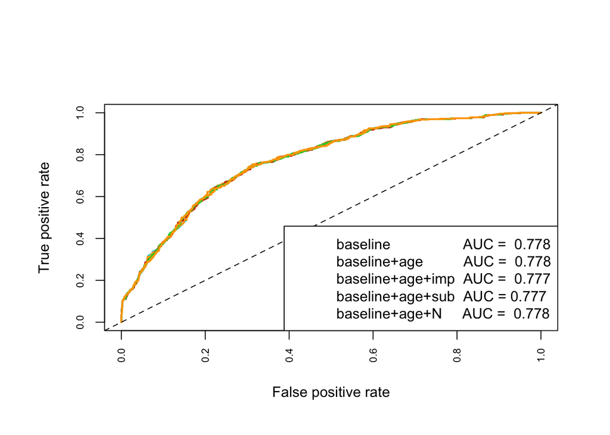

```r
plot(prf0, lwd = 2, col = cols[3])
plot(prf1, col = cols[2], add = TRUE, lwd = 2)
plot(prf2, col = cols[1], add = TRUE, lwd = 2)
plot(prf3, col = 'limegreen', add = TRUE, lwd = 2)
plot(prf4, col = 'orange', add = TRUE, lwd = 2)
abline(a = 0, b = 1, lty = 2)
legend('bottomright', paste(c('baseline                  AUC = ', 'baseline+age          AUC = ', 'baseline+age+imp  AUC = ', 'baseline+age+sub  AUC =', 'baseline+age+N     AUC = '), auc), col = cols[c(3:1, 'limegreen', 'orange')], lty = 1)
```

```r
pdf('002Incidence_AUC_constrained.pdf')
par(lwd = 3.5, cex = 1.5, cex.axis = 1.5, cex.lab = 1.5)
# Plot AUC
par(mfrow = c(1,1))
plot(prf0, lwd = 2, col = cols[3])
plot(prf1, col = cols[2], add = TRUE, lwd = 2)
plot(prf2, col = cols[1], add = TRUE, lwd = 2)
plot(prf3, col = 'limegreen', add = TRUE, lwd = 2)
plot(prf4, col = 'orange', add = TRUE, lwd = 2)
abline(a = 0, b = 1, lty = 2)
legend('bottomright', paste(c('baseline                  AUC = ', 'baseline+age          AUC = ', 'baseline+age+imp  AUC = ', 'baseline+age+sub  AUC = ', 'baseline+age+N    AUC = '), auc), col = cols[c(3:1, 'limegreen', 'orange')], lty = 1)
dev.off()
```

```r
# Calculate AUC for test data
AIC = c(fit0$aic, fit1$aic, fit2$aic, fit3$aic, fit4$aic); names(AIC) =  c('baseline', 'baseline+age', 'baseline+age+imp', 'baseline+age+sub', 'baseline+age+N')
del.AIC = sort(AIC - min(AIC))
del.AIC
```

```
##   baseline+age+N         baseline baseline+age+sub baseline+age+imp
##         0.000000         3.121122         3.919987         4.951439
##     baseline+age
##         6.483240
```

```r
load('master.AIC.table.constrained.RData')
master.AIC.table['002Incidence', c('baseline', 'baseline+age', 'baseline+age+imp', 'baseline+age+sub', 'baseline+age+N')] = AIC - min(AIC)
save(master.AIC.table, file = 'master.AIC.table.constrained.RData')
rm(master.AIC.table)
```